**City College of San Francisco**

MATH 108 - Foundations of Data Science

# Lecture 07: Charts

Associated Textbook Sections: [7.0, 7.1](https://inferentialthinking.com/chapters/07/Visualization.html)

## Set Up the Notebook

```python
from datascience import *
import numpy as np
%matplotlib inline
import matplotlib.pyplot as plots
plots.style.use('fivethirtyeight')
```

# Table of Contents

## Numerical Data

### Visualizing the Distribution of One Numerical Variable

Histograms `hist` are a standard way to visualize the distribution of one numerical variable.

*Histograms will be focused on in the next lecture.*

#### A Histogram

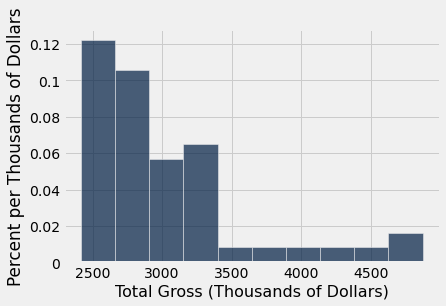

```python
actors = Table().read_table('actors.csv')
actors.hist('Total Gross', unit="Thousands of Dollars")
```

### Plotting Two Numerical Variables

Line graphs `plot` and Scatter plots `scatter` are standard ways to visualize the relationship of two numerical variables.

#### A Line Graph

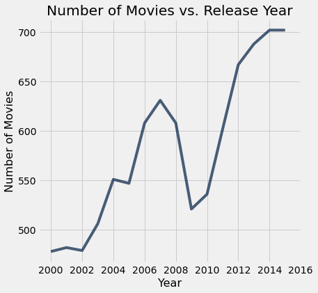

```python
movies = Table().read_table('movies_by_year.csv')
movies.where('Year', are.above(1999)).plot('Year', 'Number of Movies')
# Some extra graph formatting
plots.xticks(np.arange(2000, 2017, 2))
plots.title('Number of Movies vs. Release Year')
plots.show()
```

#### A Scatter Plot

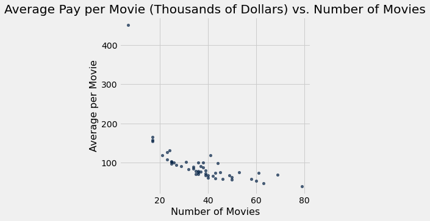

| Actor | Total Gross | Number of Movies | Average per Movie | #1 Movie | Gross |
| --- | --- | --- | --- | --- | --- |
| Harrison Ford | 4871.7 | 41 | 118.8 | Star Wars: The Force Awakens | 936.7 |
| Samuel L. Jackson | 4772.8 | 69 | 69.2 | The Avengers | 623.4 |
| Morgan Freeman | 4468.3 | 61 | 73.3 | The Dark Knight | 534.9 |
| Tom Hanks | 4340.8 | 44 | 98.7 | Toy Story 3 | 415 |
| Robert Downey, Jr. | 3947.3 | 53 | 74.5 | The Avengers | 623.4 |
| Eddie Murphy | 3810.4 | 38 | 100.3 | Shrek 2 | 441.2 |
| Tom Cruise | 3587.2 | 36 | 99.6 | War of the Worlds | 234.3 |
| Johnny Depp | 3368.6 | 45 | 74.9 | Dead Man's Chest | 423.3 |
| Michael Caine | 3351.5 | 58 | 57.8 | The Dark Knight | 534.9 |
| Scarlett Johansson | 3341.2 | 37 | 90.3 | The Avengers | 623.4 |

... (40 rows omitted)

```python
actors = Table().read_table('actors.csv')
actors.scatter('Number of Movies', 'Average per Movie')
plots.title('Average Pay per Movie (Thousands of Dollars) vs. Number of Movies')
plots.show()
actors
```

### When to use a line vs scatter plot?

- Use line plots for sequential data if:
  - ... your x-axis has an order
  - ... sequential differences in y values are meaningful
  - ... there's only one y-value for each x-value
- Usually: x-axis is time or distance
- Use scatter plots for non-sequential data --- When you’re looking for associations